# PCFL: Week 10 wrap-up

### Last week’s games

| Away | Away points | Home | Home points |
| --- | --- | --- | --- |
| Jumpin’ Jaheims | 90.86 | Athens Team Sasquatch | 117.56 |
| KC Gophers | 119.77 | Middle Earth Hangry Hobbits | 86.32 |
| Southern Sharks | 70.72 | Georgia Peanuts | 86.78 |
| First Timers The FTs | 75.70 | The G.O.A.T. | 85.35 |
| Captain Clairvoyant | 130.50 | Pigskin on the Gridiron | 88.94 |

Obligatory reminder: you should make sure to check your bye weeks and also whether your stars are active at gametime.

#### Best performing players

Here’s last week’s **10 best performing players.**

| Player | Points | Team |
| --- | --- | --- |
| Tom Brady | 31.84 | Pigskin on the Gridiron |
| Alvin Kamara | 31.30 | Athens Team Sasquatch |
| Kyler Murray | 29.90 | The G.O.A.T. |
| Ben Roethlisberger | 29.32 | KC Gophers |
| Josh Jacobs | 27.60 | The G.O.A.T. |
| Josh Allen | 26.86 | Jumpin’ Jaheims |
| Nyheim Hines | 26.00 | KC Gophers |
| Aaron Rodgers | 25.40 | Captain Clairvoyant |
| Keelan Cole Sr. | 24.85 | Pigskin on the Gridiron |
| Ronald Jones II | 24.30 | Jumpin’ Jaheims |

Tom Brady is 43 years old and (frustratingly) good at football. Kyler Murray came up with a miracle against Josh Allen, but both of those young quarterbacks had nice weeks. From a team perspective, Jacob (the GOAT) had two players in the top five this week.

#### Best addition and worst starters

There were 13 players added last week. Which was the **best new addition**?

| Date added | Name | Points | Team |
| --- | --- | --- | --- |
| 2020-11-11 | J.D. McKissic | 14.40 | Athens Team Sasquatch |
| 2020-11-11 | Jakobi Meyers | 13.36 | Jumpin’ Jaheims |
| 2020-11-11 | Graham Gano | 10.00 | Georgia Peanuts |
| 2020-11-11 | Dolphins D/ST | 8.00 | Captain Clairvoyant |
| 2020-11-11 | Packers D/ST | 7.00 | Southern Sharks |
| 2020-11-12 | Giovani Bernard | 6.70 | Athens Team Sasquatch |
| 2020-11-11 | Mason Crosby | 6.00 | Athens Team Sasquatch |
| 2020-11-12 | Dallas Goedert | 5.30 | Southern Sharks |
| 2020-11-14 | Curtis Samuel | 2.70 | The G.O.A.T. |
| 2020-11-11 | Zack Moss | 2.20 | Southern Sharks |
| 2020-11-11 | Eagles D/ST | 2.00 | Pigskin on the Gridiron |
| 2020-11-12 | Austin Hooper | 1.60 | KC Gophers |
| 2020-11-14 | Jimmy Graham | 0.00 | The G.O.A.T. |

No breakout scorers this week, but McKissic and Meyers were both nice pickups.

Who won the **best scoring bench** award last week?

| Team | Points |
| --- | --- |
| Jumpin’ Jaheims | 114.95 |
| Pigskin on the Gridiron | 84.14 |
| First Timers The FTs | 68.72 |
| KC Gophers | 64.67 |
| Georgia Peanuts | 64.26 |
| Captain Clairvoyant | 59.60 |
| Middle Earth Hangry Hobbits | 51.63 |
| The G.O.A.T. | 41.18 |
| Athens Team Sasquatch | 39.82 |
| Southern Sharks | 19.10 |

Evan’s bench easily outscored his starters this week. If you haven’t noticed, Sarah’s bench is now more or less empty.

### League standings and season stats

Here’s a look at our current standings

| Team | Division | W | L | Points scored | Points allowed | Points rank | Playoff rank |
| --- | --- | --- | --- | --- | --- | --- | --- |
| Captain Clairvoyant | Grits | 8 | 2 | 1185.23 | 1056.20 | 2 | 1 |
| Athens Team Sasquatch | Grits | 8 | 2 | 1118.06 | 1057.78 | 3 | 2 |
| Georgia Peanuts | Hot Dish | 7 | 3 | 1273.80 | 1091.92 | 1 | 3 |
| The G.O.A.T. | Grits | 6 | 4 | 1075.03 | 1123.82 | 7 | 4 |
| KC Gophers | Hot Dish | 5 | 5 | 1077.61 | 1090.63 | 6 | 5 |
| Southern Sharks | Hot Dish | 5 | 5 | 1069.38 | 1045.21 | 8 | 6 |
| Pigskin on the Gridiron | Grits | 4 | 6 | 1047.36 | 1130.54 | 9 | 7 |
| First Timers The FTs | Hot Dish | 3 | 7 | 1084.30 | 1157.47 | 5 | 8 |
| Middle Earth Hangry Hobbits | Hot Dish | 2 | 8 | 1084.96 | 1150.79 | 4 | 9 |
| Jumpin’ Jaheims | Grits | 2 | 8 | 1017.44 | 1128.81 | 10 | 10 |

Here’s our current awards leaders from these standings:

- Yellow shirt (most points): Georgia Peanuts
- D-FENCE (least points allowed): Southern Sharks
- Tough luck (points rank - playoff rank): Hibbits (4th and 9th) (*new*)
- Lucky ducks (playoff rank - points rank): The GOAT (7th in points, 4th in the standings)

Here’s a list of the **top five scoring performances** so far this season.

| Team | Week | Points scored | Result |
| --- | --- | --- | --- |
| Georgia Peanuts | 8 | 183.82 | W |
| First Timers The FTs | 2 | 171.28 | W |
| Georgia Peanuts | 7 | 163.68 | W |
| Georgia Peanuts | 9 | 152.14 | W |
| Captain Clairvoyant | 3 | 150.32 | W |

No changes this week.

Lastly, here’s a look at the **points trendline** for each team.

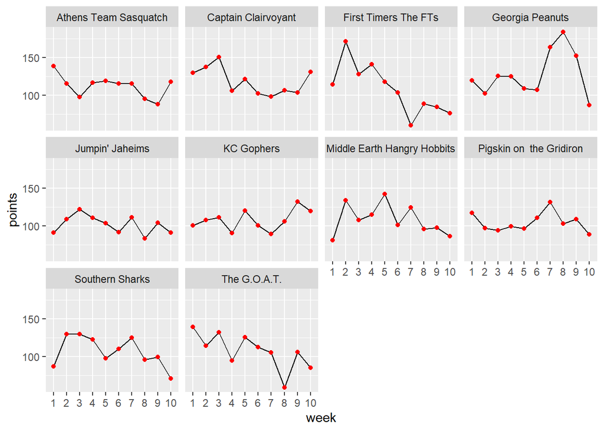

### Playoff picture

There’s now four weeks left in the season. If it ended today, our division leaders would be me and Brian (tied with Robbie, but winner on points). The wildcards would be Robbie and Jacob. Time is starting to run out on the Hobbits and Jumpin’ Jaheims, but no one is eliminated yet.

## Next week’s games

Here’s a quick summary of next week’s matchups:

| week | away_team | away_points | home_team | home_points | range |
| --- | --- | --- | --- | --- | --- |
| 11 | Southern Sharks | 1069.38 | Middle Earth Hangry Hobbits | 1084.96 | 15.58 |
| 11 | The G.O.A.T. | 1075.03 | Athens Team Sasquatch | 1118.06 | 43.03 |
| 11 | Jumpin’ Jaheims | 1017.44 | Captain Clairvoyant | 1185.23 | 167.79 |
| 11 | First Timers The FTs | 1084.30 | KC Gophers | 1077.61 | 6.69 |
| 11 | Georgia Peanuts | 1273.80 | Pigskin on the Gridiron | 1047.36 | 226.44 |

At the top of the standings, Brian goes up against Evan and Robbie faces down the GOAT. It’s a crucial week for Scott, as the Hobbits swim with the Sharks, as well as for Evan to stay alive for the playoffs. Christine looks to continue her hot streak against the First Timers, and I match up with Richard. Good luck all!